# Practical Machine Learning Course Project

Osian Davies

14 January 2018

## Introduction

Using devices such as Jawbone Up, Nike FuelBand, and Fitbit, it is now possible to collect a large amount of data about personal activity relatively inexpensively. These type of devices are part of the quantified self movement - a group of enthusiasts who take measurements about themselves regularly to improve their health, to find patterns in their behavior, or because they are tech geeks. One thing that people regularly do is quantify how much of a particular activity they do, but they rarely quantify how well they do it. In this project, your goal will be to use data from accelerometers on the belt, forearm, arm, and dumbell of 6 participants. They were asked to perform barbell lifts correctly and incorrectly in 5 different ways. More information is available from the website here: http://groupware.les.inf.puc-rio.br/har (see the section on the Weight Lifting Exercise Dataset).

### Project Aims:

The training data for this project are available here:

https://d396qusza40orc.cloudfront.net/predmachlearn/pml-training.csv

The test data are available here:

https://d396qusza40orc.cloudfront.net/predmachlearn/pml-testing.csv

The data for this project come from this source: http://groupware.les.inf.puc-rio.br/har

## Preparing the R Workspace and Exploratory Analysis

First I imported the data into R,

```r
raw.test <- read.csv(file = "pml-testing.csv", header = T)
raw.training <- read.csv(file = "pml-training.csv", header = T)
```

and then did some exploring on the training dataset.

```r
dim(raw.training)
```

```
## [1] 19622   160
```

There are 160 variables - many of which will negatively affect for model. Therefore I’ve decided to sensibly narrow down the amount of variables needed.

The first 7 columns consists of IDs, usernames and timestamps. I will first remove these columns as I believe that they won’t be needed.

```r
wip.training <- raw.training[-(1:7)]
```

Many columns contains NAs, so first to check how NAs is distributed among all columns.

```r
colSums(is.na(wip.training))
```

```
##                roll_belt               pitch_belt                 yaw_belt
##                        0                        0                        0
##         total_accel_belt       kurtosis_roll_belt      kurtosis_picth_belt
##                        0                        0                        0
##        kurtosis_yaw_belt       skewness_roll_belt     skewness_roll_belt.1
##                        0                        0                        0
##        skewness_yaw_belt            max_roll_belt           max_picth_belt
##                        0                    19216                    19216
##             max_yaw_belt            min_roll_belt           min_pitch_belt
##                        0                    19216                    19216
##             min_yaw_belt      amplitude_roll_belt     amplitude_pitch_belt
##                        0                    19216                    19216
##       amplitude_yaw_belt     var_total_accel_belt            avg_roll_belt
##                        0                    19216                    19216
##         stddev_roll_belt            var_roll_belt           avg_pitch_belt
##                    19216                    19216                    19216
##        stddev_pitch_belt           var_pitch_belt             avg_yaw_belt
##                    19216                    19216                    19216
##          stddev_yaw_belt             var_yaw_belt             gyros_belt_x
##                    19216                    19216                        0
##             gyros_belt_y             gyros_belt_z             accel_belt_x
##                        0                        0                        0
##             accel_belt_y             accel_belt_z            magnet_belt_x
##                        0                        0                        0
##            magnet_belt_y            magnet_belt_z                 roll_arm
##                        0                        0                        0
##                pitch_arm                  yaw_arm          total_accel_arm
##                        0                        0                        0
##            var_accel_arm             avg_roll_arm          stddev_roll_arm
##                    19216                    19216                    19216
##             var_roll_arm            avg_pitch_arm         stddev_pitch_arm
##                    19216                    19216                    19216
##            var_pitch_arm              avg_yaw_arm           stddev_yaw_arm
##                    19216                    19216                    19216
##              var_yaw_arm              gyros_arm_x              gyros_arm_y
##                    19216                        0                        0
##              gyros_arm_z              accel_arm_x              accel_arm_y
##                        0                        0                        0
##              accel_arm_z             magnet_arm_x             magnet_arm_y
##                        0                        0                        0
```

[output cut: 47 more lines]

```
##                    19216                    19216                        0
##      total_accel_forearm        var_accel_forearm         avg_roll_forearm
##                        0                    19216                    19216
##      stddev_roll_forearm         var_roll_forearm        avg_pitch_forearm
##                    19216                    19216                    19216
##     stddev_pitch_forearm        var_pitch_forearm          avg_yaw_forearm
##                    19216                    19216                    19216
##       stddev_yaw_forearm          var_yaw_forearm          gyros_forearm_x
##                    19216                    19216                        0
##          gyros_forearm_y          gyros_forearm_z          accel_forearm_x
##                        0                        0                        0
##          accel_forearm_y          accel_forearm_z         magnet_forearm_x
##                        0                        0                        0
##         magnet_forearm_y         magnet_forearm_z                   classe
##                        0                        0                        0
```

We can see that these columns either have the majority of the observations being NAs or they don’t have any NAs at all. Hence I remove all columns with NAs.

```r
wip.training <- wip.training[sapply(wip.training, function(x) !any(is.na(x)))]
```

Finally, I will also check for variables with near zero variance - this will get rid of variables that are (near) constant and missing values.

```r
nzv <- nearZeroVar(wip.training, saveMetrics = T)
wip.training <- wip.training[,nzv$nzv == FALSE]
```

Preparing the data - done!

```r
train <- wip.training
```

## Splitting Data To Get Training and Test sets

I will split the prepared dataframe into a training set and a test set which we can use to help predict the classe of the values in the testing csv file. I will partition this dataframe into 60% training and 40% testing sets.

```r
set.seed(123)
part <- createDataPartition(y = train$classe, p = 0.6, list = FALSE)
train.Train <- train[part,]
train.Test <- train[-part,]
```

## Model Building

We first look at predicting classe values using the Decision Tree algorithm.

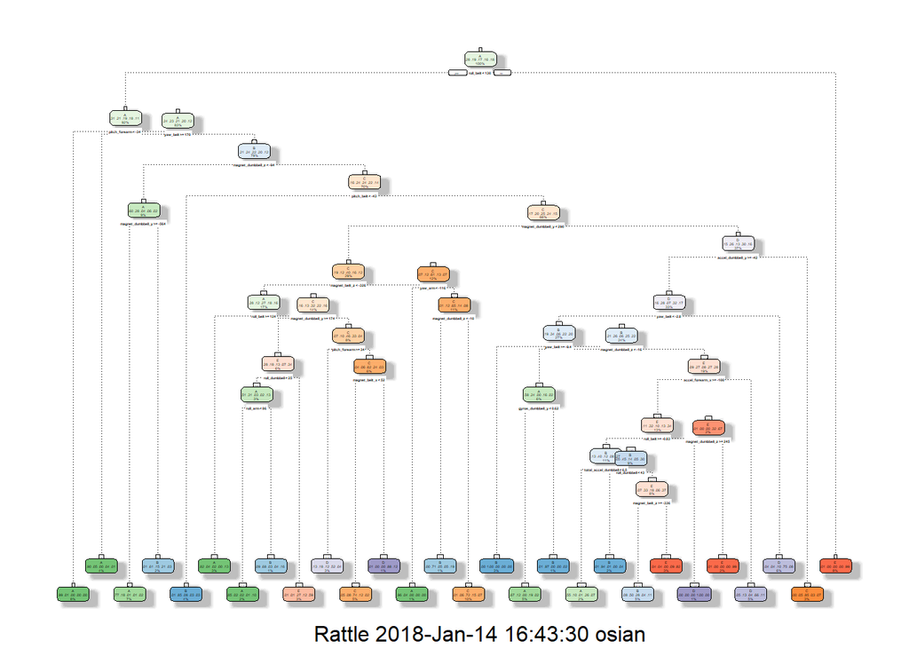

```r
DT.Fit <- rpart(classe ~ ., data = train.Train, method = "class")
fancyRpartPlot(DT.Fit)
```

Now I use this to predict the results of the test data and build a confusion Matrix to test the results with the actual results.

```r
predictionDT <- predict(DT.Fit, train.Test, type = "class")
confusionMatrix(predictionDT, train.Test$classe)
```

```
## Confusion Matrix and Statistics
##
##           Reference
## Prediction    A    B    C    D    E
##          A 2059  203   18  128   79
##          B   60 1086  211   70   93
##          C   20   83  998  184   83
##          D   71  138   81  863  120
##          E   22    8   60   41 1067
##
## Overall Statistics
##
##                Accuracy : 0.774
##                  95% CI : (0.7646, 0.7832)
##     No Information Rate : 0.2845
##     P-Value [Acc > NIR] : < 2.2e-16
##
##                   Kappa : 0.713
##  Mcnemar's Test P-Value : < 2.2e-16
##
## Statistics by Class:
##
##                      Class: A Class: B Class: C Class: D Class: E
## Sensitivity            0.9225   0.7154   0.7295   0.6711   0.7399
## Specificity            0.9238   0.9314   0.9429   0.9375   0.9795
## Pos Pred Value         0.8279   0.7145   0.7295   0.6779   0.8907
## Neg Pred Value         0.9677   0.9317   0.9429   0.9356   0.9436
## Prevalence             0.2845   0.1935   0.1744   0.1639   0.1838
## Detection Rate         0.2624   0.1384   0.1272   0.1100   0.1360
## Detection Prevalence   0.3170   0.1937   0.1744   0.1622   0.1527
## Balanced Accuracy      0.9231   0.8234   0.8362   0.8043   0.8597
```

Here we had a result of around 77% accuracy. With a out-sample error of 23%, this result is not yet know to be good or bad, so need to compare this with another algorithm.

So for (maybe hopefully) better results, I will now try predicting values using the Random Forests algorithm.

```r
RF.Fit <- randomForest(classe ~ . , data = train.Train)
predictionRF <- predict(RF.Fit, train.Train, type = "class")
confusionMatrix(predictionRF, train.Train$classe)
```

```
## Confusion Matrix and Statistics
##
##           Reference
## Prediction    A    B    C    D    E
##          A 3348    0    0    0    0
##          B    0 2279    0    0    0
##          C    0    0 2054    0    0
##          D    0    0    0 1930    0
##          E    0    0    0    0 2165
##
## Overall Statistics
##
##                Accuracy : 1
##                  95% CI : (0.9997, 1)
##     No Information Rate : 0.2843
##     P-Value [Acc > NIR] : < 2.2e-16
##
##                   Kappa : 1
##  Mcnemar's Test P-Value : NA
##
## Statistics by Class:
##
##                      Class: A Class: B Class: C Class: D Class: E
## Sensitivity            1.0000   1.0000   1.0000   1.0000   1.0000
## Specificity            1.0000   1.0000   1.0000   1.0000   1.0000
## Pos Pred Value         1.0000   1.0000   1.0000   1.0000   1.0000
## Neg Pred Value         1.0000   1.0000   1.0000   1.0000   1.0000
## Prevalence             0.2843   0.1935   0.1744   0.1639   0.1838
## Detection Rate         0.2843   0.1935   0.1744   0.1639   0.1838
## Detection Prevalence   0.2843   0.1935   0.1744   0.1639   0.1838
## Balanced Accuracy      1.0000   1.0000   1.0000   1.0000   1.0000
```

## Generating results as answers for the assignment

I will now use the Random Forests algorithm to predict the classe for the testing data.

```r
prediction <- predict(RF.Fit, raw.test, type = "class")
prediction
```

```
##  1  2  3  4  5  6  7  8  9 10 11 12 13 14 15 16 17 18 19 20
##  B  A  B  A  A  E  D  B  A  A  B  C  B  A  E  E  A  B  B  B
## Levels: A B C D E
```